# Data Overview and Outlier Assessment

Catalina Valencia

**Project:** US Crime Rate Modeling: Regression, Regularization, and Tree-Based Methods

**File:** 01_data_overview_and_preparation.Rmd

### Objectives:

- Load and summarize the US crime dataset.
- Examine the distribution of crime rates.
- Assess potential outliers in the response variable (Crime).
- Apply Grubbs’ test in a structured and interpretable manner.
- Document decisions regarding outlier treatment and scaling.

### Notes:

- Outlier detection is conducted as an exploratory data quality check.
- No observations are removed due to the small sample size.
- The original dataset is retained for all subsequent analyses.

Environment Setup

```r
rm(list = ls())
```

Load Required Libraries

```r
library(outliers)
```

Load Data

```r
uscrime <- read.table(
  "../data/uscrime.txt",
  header = TRUE,
  stringsAsFactors = FALSE
)
```

### Data Overview

```r
head(uscrime)
```

```
##      M So   Ed  Po1  Po2    LF   M.F Pop   NW    U1  U2 Wealth Ineq     Prob
## 1 15.1  1  9.1  5.8  5.6 0.510  95.0  33 30.1 0.108 4.1   3940 26.1 0.084602
## 2 14.3  0 11.3 10.3  9.5 0.583 101.2  13 10.2 0.096 3.6   5570 19.4 0.029599
## 3 14.2  1  8.9  4.5  4.4 0.533  96.9  18 21.9 0.094 3.3   3180 25.0 0.083401
## 4 13.6  0 12.1 14.9 14.1 0.577  99.4 157  8.0 0.102 3.9   6730 16.7 0.015801
## 5 14.1  0 12.1 10.9 10.1 0.591  98.5  18  3.0 0.091 2.0   5780 17.4 0.041399
## 6 12.1  0 11.0 11.8 11.5 0.547  96.4  25  4.4 0.084 2.9   6890 12.6 0.034201
##      Time Crime
## 1 26.2011   791
## 2 25.2999  1635
## 3 24.3006   578
## 4 29.9012  1969
## 5 21.2998  1234
## 6 20.9995   682
```

```r
tail(uscrime)
```

```
##       M So   Ed  Po1 Po2    LF   M.F Pop   NW    U1  U2 Wealth Ineq     Prob
## 42 14.1  0 10.9  5.6 5.4 0.523  96.8   4  0.2 0.107 3.7   4890 17.0 0.088904
## 43 16.2  1  9.9  7.5 7.0 0.522  99.6  40 20.8 0.073 2.7   4960 22.4 0.054902
## 44 13.6  0 12.1  9.5 9.6 0.574 101.2  29  3.6 0.111 3.7   6220 16.2 0.028100
## 45 13.9  1  8.8  4.6 4.1 0.480  96.8  19  4.9 0.135 5.3   4570 24.9 0.056202
## 46 12.6  0 10.4 10.6 9.7 0.599  98.9  40  2.4 0.078 2.5   5930 17.1 0.046598
## 47 13.0  0 12.1  9.0 9.1 0.623 104.9   3  2.2 0.113 4.0   5880 16.0 0.052802
##       Time Crime
## 42 12.1996   542
## 43 31.9989   823
## 44 30.0001  1030
## 45 32.5996   455
## 46 16.6999   508
## 47 16.0997   849
```

```r
summary(uscrime)
```

```
##        M               So               Ed             Po1
##  Min.   :11.90   Min.   :0.0000   Min.   : 8.70   Min.   : 4.50
##  1st Qu.:13.00   1st Qu.:0.0000   1st Qu.: 9.75   1st Qu.: 6.25
##  Median :13.60   Median :0.0000   Median :10.80   Median : 7.80
##  Mean   :13.86   Mean   :0.3404   Mean   :10.56   Mean   : 8.50
##  3rd Qu.:14.60   3rd Qu.:1.0000   3rd Qu.:11.45   3rd Qu.:10.45
##  Max.   :17.70   Max.   :1.0000   Max.   :12.20   Max.   :16.60
##       Po2               LF              M.F              Pop
##  Min.   : 4.100   Min.   :0.4800   Min.   : 93.40   Min.   :  3.00
##  1st Qu.: 5.850   1st Qu.:0.5305   1st Qu.: 96.45   1st Qu.: 10.00
##  Median : 7.300   Median :0.5600   Median : 97.70   Median : 25.00
##  Mean   : 8.023   Mean   :0.5612   Mean   : 98.30   Mean   : 36.62
##  3rd Qu.: 9.700   3rd Qu.:0.5930   3rd Qu.: 99.20   3rd Qu.: 41.50
##  Max.   :15.700   Max.   :0.6410   Max.   :107.10   Max.   :168.00
##        NW              U1                U2            Wealth
##  Min.   : 0.20   Min.   :0.07000   Min.   :2.000   Min.   :2880
##  1st Qu.: 2.40   1st Qu.:0.08050   1st Qu.:2.750   1st Qu.:4595
##  Median : 7.60   Median :0.09200   Median :3.400   Median :5370
##  Mean   :10.11   Mean   :0.09547   Mean   :3.398   Mean   :5254
##  3rd Qu.:13.25   3rd Qu.:0.10400   3rd Qu.:3.850   3rd Qu.:5915
##  Max.   :42.30   Max.   :0.14200   Max.   :5.800   Max.   :6890
##       Ineq            Prob              Time           Crime
##  Min.   :12.60   Min.   :0.00690   Min.   :12.20   Min.   : 342.0
##  1st Qu.:16.55   1st Qu.:0.03270   1st Qu.:21.60   1st Qu.: 658.5
##  Median :17.60   Median :0.04210   Median :25.80   Median : 831.0
##  Mean   :19.40   Mean   :0.04709   Mean   :26.60   Mean   : 905.1
##  3rd Qu.:22.75   3rd Qu.:0.05445   3rd Qu.:30.45   3rd Qu.:1057.5
##  Max.   :27.60   Max.   :0.11980   Max.   :44.00   Max.   :1993.0
```

Variable of Interest: crime represents the number of crimes per 100,000 people

```r
crime <- uscrime$Crime
```

### Exploratory Distribution Diagnostics

- Examine the distributional shape of the crime rate variable.
- Identify potential deviations from normality.
- Visually assess the presence of extreme values.

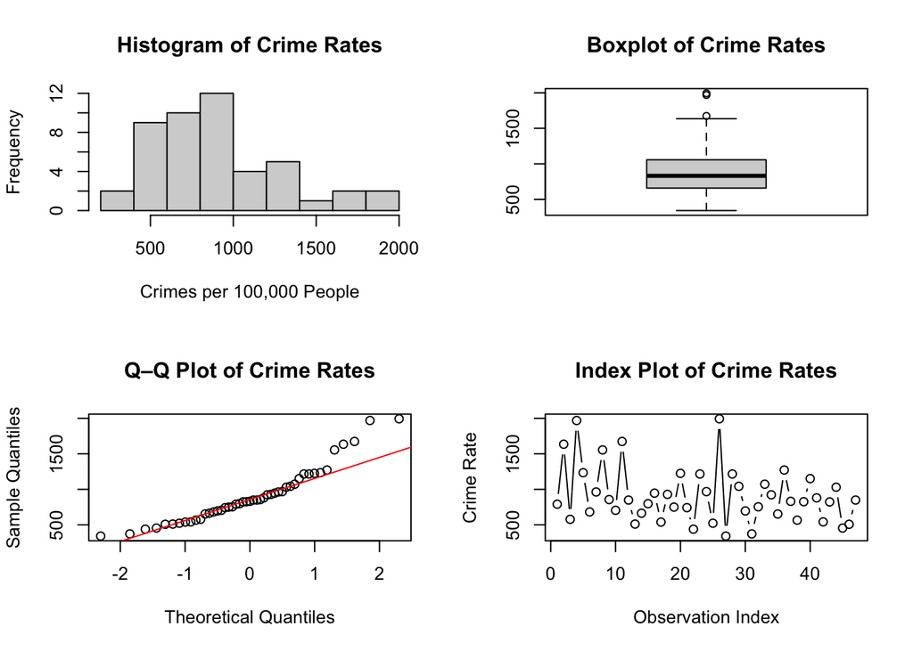

```r
par(mfrow = c(2, 2))

hist(
  crime,
  main = "Histogram of Crime Rates",
  xlab = "Crimes per 100,000 People"
)

boxplot(
  crime,
  main = "Boxplot of Crime Rates"
)

qqnorm(crime, main = "Q–Q Plot of Crime Rates")
qqline(crime, col = "red")

plot(
  crime,
  type = "b",
  main = "Index Plot of Crime Rates",
  ylab = "Crime Rate",
  xlab = "Observation Index"
)
```

```r
par(mfrow = c(1, 1))
```

**Normality Assessment**

- Formally test the normality assumption
- Interpret results in conjunction with visual diagnostics

```r
shapiro.test(crime)
```

```
##
##  Shapiro-Wilk normality test
##
## data:  crime
## W = 0.91273, p-value = 0.001882
```

**Results:**

Shapiro–Wilk test statistic W = 0.9127, with p-value = 0.0019.

- The test rejects the null hypothesis of normality at p < 0.05.
- Visual diagnostics suggest the distribution is positively skewed (right-skewed). While the central portion appears approximately symmetric and normally distributed, departures from normality are driven by the upper tail containing several potential outliers.

With these findings, Grubbs’ test is applied cautiously and interpreted in conjunction with graphical evidence.

### Grubbs’ Test for Outliers

- Identify potential extreme observations in the crime rate.
- Evaluate whether high or low values constitute statistical outliers.

**Test for two-sided outliers (both extremes simultaneously)**

```r
grubbs.test(crime, type = 11)
```

```
##
##  Grubbs test for two opposite outliers
##
## data:  crime
## G = 4.26877, U = 0.78103, p-value = 1
## alternative hypothesis: 342 and 1993 are outliers
```

**Results:**

Grubbs’ test for two opposite outliers yields:

G = 4.2688,

U = 0.7810,

p-value = 1.00.

With a p-value of 1.00, the test provides no evidence that the extreme observations are statistically significant outliers. This result supports separate evaluation of the lower and upper extremes rather than reliance on a two-sided Grubbs’ test alone.

**Test for a single high-end outlier**

```r
grubbs.test(crime, type = 10)
```

```
##
##  Grubbs test for one outlier
##
## data:  crime
## G = 2.81287, U = 0.82426, p-value = 0.07887
## alternative hypothesis: highest value 1993 is an outlier
```

**Results:**

One-sided Grubbs’ test (upper tail) yields:

G = 2.8129,

U = 0.8243,

p-value = 0.0789.

There is no statistically significant evidence that the largest crime rate is an outlier. However, since the value is relatively extreme, it is examined further in subsequent tests.

Remove the highest value and test again

```r
crime2 <- crime[-which.max(crime)]

grubbs.test(crime2, type = 10)
```

```
##
##  Grubbs test for one outlier
##
## data:  crime2
## G = 3.06343, U = 0.78682, p-value = 0.02848
## alternative hypothesis: highest value 1969 is an outlier
```

**Results:**

After removing the highest value, the Grubbs’ test yields:

G = 3.0634,

U = 0.7868,

p-value = 0.0285.

At the 5% significance level, this result indicates that the largest remaining observation is statistically significant as a high-end outlier. Thus, the second-highest crime rate is also flagged as a potential outlier.

**Test for a low-end outlier after removing the two highest values**

```r
crime3 <- crime2[-which.max(crime2)]

grubbs.test(crime3, type = 10, opposite = TRUE)
```

```
##
##  Grubbs test for one outlier
##
## data:  crime3
## G = 1.61796, U = 0.93915, p-value = 1
## alternative hypothesis: lowest value 342 is an outlier
```

**Results:**

G = 1.6180,

U = 0.9392,

p-value = 1.

This result provides no evidence of a statistically significant low-end outlier. Therefore, once the two largest observations are removed, the remaining data do not exhibit further outliers at the lower tail.

**Outlier Assessment Summary**

- A two-sided Grubbs’ test finds no statistically significant outliers, prompting separate evaluation of upper and lower tails.
- Sequential one-sided tests identify two high-end observations of concern, with statistical significance reached for the second-highest value after removal of the maximum.
- No low-end outliers are detected, and further iteration provides no evidence to remove additional observations.

**Final Decision**

Given the small sample size (n = 47) and the substantive plausibility of extreme crime rates, no observations are removed from the dataset. The full, original dataset is retained for all subsequent analyses to avoid bias introduced by aggressive trimming or over-cleaning.

### Scaling Considerations

Predictors in the dataset span different numeric ranges. Feature scaling is considered in downstream modeling steps where scale sensitivity is relevant.

No scaling is applied at this stage in order to preserve the original measurement scale during exploratory analysis.